# $\color{brown}{\text{Stock Price Forecasting: A Data-Driven Approach to Uncover Market Trends}}$

## Intraday Price Movement:

The difference between the opening and adjusted closing prices provides insight into how much the price of a financial instrument has moved within a single trading day. It gives you a sense of intraday volatility.

## Market Sentiment:

Positive values (df['Adj Close'] > df['Open']) suggest that the closing price was higher than the opening price, potentially indicating positive market sentiment or buying pressure during the day. Negative values (df['Adj Close'] < df['Open']) suggest that the closing price was lower than the opening price, potentially indicating negative market sentiment or selling pressure during the day.

```python
data['Target'] = data['Adj Close']- data['Open']
data.tail(10)
data['Target'] = data['Target'].shift(-1)
```

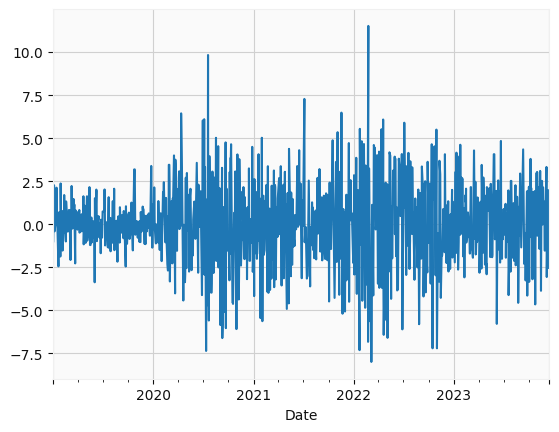

```python
data['Target'].plot()
```

# Feature Enginnering

data['Target'] = data['Adj Close'] - data['Open']

data['Target'] = data['Target'].shift(-1)

The significance of this transformation is in the preparation of the dataset for a predictive model, where we want to predict the next day's price change based on today's data. By shifting the 'Target' up, we're saying: "Given today's open price and adjusted close price, what will be the change in price when the market opens next?"

Here's what the dataset is being prepared to predict with this new 'Target' feature:

If Target is positive, it means the stock closed higher than it opened the next day (an upward movement). If Target is negative, it means the stock closed lower than it opened the next day (a downward movement).

```python
data['TargetClass'] = [1 if data.Target[i] > 0 else 0 for i in range(len(data))]
```

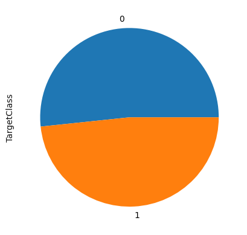

```python
data['TargetClass'].value_counts().plot(kind='pie' )
```

Quarter end : A quarter is defined as company portforlio in a span of three months. Every company prepares its quarterly results and publishes them publicly so, that people can analyze the company’s performance. These quarterly results affect the stock prices heavily and can be a helpful feature for the learning model.

```python
data["is_quarter_end"]  = np.where(data.index.month % 3 ==0,1,0)
data
```

[output not shown]

1808 rows × 15 columns

```python
data.groupby('is_quarter_end').mean()
```

| is_quarter_end | Open | High | Low | Close | Adj Close | Volume | RSI | Target | TargetClass | Year | dayofweek | day_of_month | week_of_month | month |
| --- | --- | --- | --- | --- | --- | --- | --- | --- | --- | --- | --- | --- | --- | --- |
| 0 | 127.648812 | 129.191250 | 125.970548 | 127.602142 | 127.602142 | 7.892401e+07 | 52.834395 | -0.058868 | 0.484774 | 2021.000823 | 3.007407 | 15.726749 | 2.698765 | 6.037860 |
| 1 | 126.875908 | 128.282083 | 125.119574 | 126.716206 | 126.716206 | 7.603942e+07 | 53.028129 | -0.141182 | 0.480607 | 2020.942664 | 2.983137 | 15.546374 | 2.674536 | 7.370995 |

Prices are higher in the months which are not quarter end as compared to that of the quarter end months.

The volume of trades is lower in the months which are quarter end.

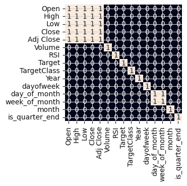

```python
plt.figure(figsize=(3, 3))

# As our concern is with the highly
# correlated features only so, we will visualize
# our heatmap as per that criteria only.
sb.heatmap(data.corr() > 0.9, annot=True, cbar=False)
plt.show()
```

```python
data['TargetNextClose'] = data['Adj Close'].shift(-1)
```

# Time Series Model

The choice of the best model for time series analysis of stocks depends on various factors, including the characteristics of the data, the specific problem we are trying to incorporate, and the trade-offs that we are willing to make between model complexity and interpretability.

```
# This is formatted as code
```

A time series consists of three systematic components: level, trend, and seasonality, along with a non-systematic component known as noise.

The definitions of these components are as follows:

- Level: The average value observed in the series.
- Trend: The upward or downward movement observed in the series over time.
- Seasonality: The recurring short-term cycles or patterns observed in the series.
- Noise: The random fluctuations or variance present in the series.

Before performing time series analysis, it is essential to determine whether the series is stationary since time series analysis assumes stationarity.

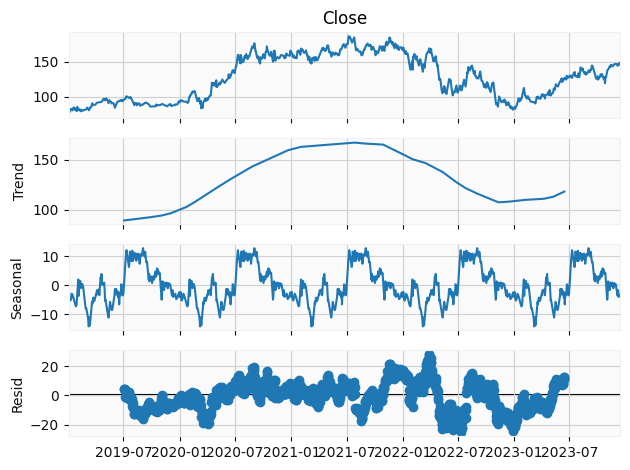

```python
from statsmodels.tsa.seasonal import seasonal_decompose
decompose= seasonal_decompose(data.Close, period=365)
decompose.plot()
plt.show()
```

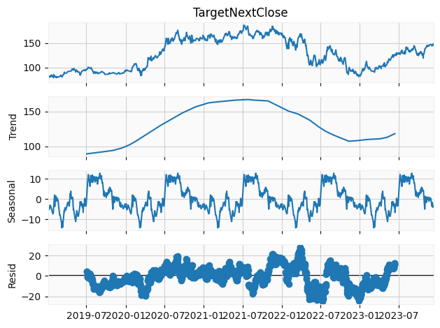

```python
from statsmodels.tsa.seasonal import seasonal_decompose
decompose= seasonal_decompose(data.TargetNextClose.dropna(), period=365)
decompose.plot()
plt.show()
```

### ADF (Augmented Dickey-Fuller) Test test is a statistical test :

used to determine whether a time series is stationary or non-stationary based on the presence of a unit root.

A unit root refers to a root of the autoregressive (AR) characteristic equation that is equal to 1. If a time series has a unit root, it implies that the series is non-stationary, meaning it does not exhibit a constant mean or variance over time.

When a series has a unit root, it tends to follow a random walk pattern, where the future values are highly dependent on the current value and exhibit no clear trend or predictable patterns. Unit roots introduce a high degree of persistence in the series, making it difficult to make accurate forecasts or analyze the underlying behavior.

In general, an AR(p) model is represented by the following equation:

y(t) = c + φ₁ *y(t-1) + φ₂* y(t-2) + ... + φₚ * y(t-p) + ε(t)

where:

y(t) represents the value of the time series at time t. c is a constant term. φ₁, φ₂, ..., φₚ are the coefficients corresponding to the lagged values. ε(t) is the error term or the random component of the model. The characteristic equation of an AR(p) model is obtained by rearranging the equation and setting y(t) equal to the lagged values:

y(t) - φ₁ *y(t-1) - φ₂* y(t-2) - ... - φₚ * y(t-p) = c + ε(t) Simplifying further, we get:

y(t) - φ₁ *y(t-1) - φ₂* y(t-2) - ... - φₚ * y(t-p) - c = ε(t)

When there is a unit root present in the series, it means that the roots of the characteristic equation are equal to 1. In other words, the equation has a root of 1, which indicates non-stationarity.

### Hypothesis

Null Hypothesis: The series has a unit root (value of a =1)

Alternate Hypothesis: The series has no unit root.

If the null hypothesis is rejected, the series is said to be stationary. The series can be linear or difference stationary as a result of this.

```python
from statsmodels.tsa.stattools import adfuller
def adf_test(timeseries):
    print ('Results of Dickey-Fuller Test:')
    dftest = adfuller(timeseries, autolag='AIC')
    dfoutput = pd.Series(dftest[0:4], index=['Test Statistic','p-value','#Lags Used','Number of Observations Used'])
    for key,value in dftest[4].items():
        dfoutput['Critical Value (%s)'%key] = value
    print (dfoutput)
adf_test(data['Close'])
```

```
Results of Dickey-Fuller Test:
Test Statistic                   -1.908326
p-value                           0.328154
#Lags Used                        1.000000
Number of Observations Used    1806.000000
Critical Value (1%)              -3.433976
Critical Value (5%)              -2.863142
Critical Value (10%)             -2.567623
dtype: float64
```

```python
from statsmodels.tsa.stattools import adfuller

# Assuming 'series' is your time series data
result = adfuller(data['Close'])

# Extract the p-value and test statistic
p_value = result[1]
test_statistic = result[0]

# Compare the p-value with the significance level to determine stationarity
if p_value < 0.05:
    print("The series is stationary.")
else:
    print("The series is non-stationary.")
```

```
The series is non-stationary.
```

As the series is non-stationary we need to see iff we can convert it to stationary i.e. its statistical properties such as mean, variance remain constant over time.

Some classic Model like AR, MA, ARIMA make certain statistical assumptions about the properties of the data, such as constant mean, constant variance and autocovariance that does not depend on time.

Just to mention all time series models dnt require the data to be stationary. Some models, like some forms of recurrent neural networks or state space models, can handle non-stationary data. But for classical models like AR, MA, and ARIMA, stationarity is a fundamental assumption.

If the time series is not stationary, it can be transformed to stationary via techniques like differencing, logarithms, or other mathematical transformations. Once the model has been built and used to forecast future time points, the transformations can be reversed to obtain actual predicted values.

### Converting non-stationary to stationary time series

1. Differencing: by differencing the series and using a lagged version of the series. This is done by subtracting the previous observation from the current observation. To go further deeper if it doesn't work is to take the second difference, third, and so forth.
2. Log Transformation: log transformation can be use to stabilize the variance of the time series.
3. Decomposition: Time series as a combination of level, trend, seasonality, and noise components. These components can be separated out into distinct series for analysis and use residual time series for forecasting.

We need to convert back these series after forecasting on the differenced or transformed series to get predictions on the original scale.

```
Results of Dickey-Fuller Test:
Test Statistic                  -45.008663
p-value                           0.000000
#Lags Used                        0.000000
Number of Observations Used    1806.000000
Critical Value (1%)              -3.433976
Critical Value (5%)              -2.863142
Critical Value (10%)             -2.567623
dtype: float64
```

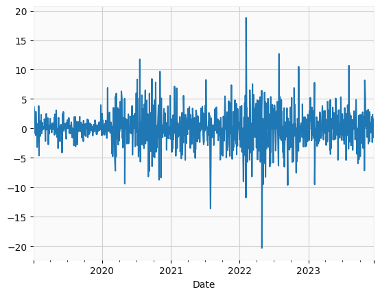

```python
data['Close_diff'] = data['Close'].diff()
data['Close_diff'].dropna().plot()
adf_test(data['Close_diff'].dropna())
```

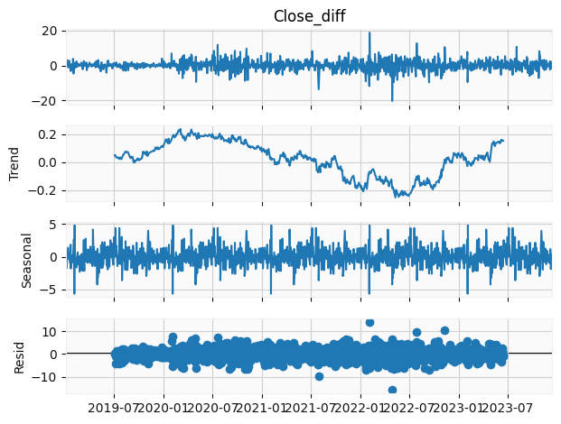

```python
seasonal_decompose(data.Close_diff.dropna(), period=365).plot()
plt.show()
```

[output not shown]

[figure not shown]

```python
data['Close_log'] = np.log(data['Close'])
data['Close_log_diff'] = data['Close_log'].diff()
data['Close_log_diff'].dropna().plot()
adf_test(data['Close_log_diff'].dropna())
```

```python
#from statsmodels.tsa.seasonal import seasonal_decompose
#decomposition = seasonal_decompose(data['Close'])

#trend = decomposition.trend
#seasonal = decomposition.seasonal
#residual = decomposition.resid

#residual.dropna().plot()
```

```python
train=data[(data.index<="2023-09-30")]
test=data[(data.index>"2023-09-30")]
```

```python
train.shape
```

```
(1733, 17)
```

```python
train
```

[output not shown]

```python
test.shape
```

```
(75, 17)
```

### AR (Autoregressive) Models:

The Autoregressive (AR) model uses the dependent relationship between an observation and some number of lagged observations (observations at prior points in time). For instance, an AR(1) model would predict the value at the present time based on the value at the previous time.

Benefits of AR Models:

1.They're simple to understand and implement.  
2.They're relatively efficient in terms of computational resources.

I got this error ""/usr/local/lib/python3.11/site-packages/statsmodels/tsa/base/tsa_model.py:473: ValueWarning: A date index has been provided, but it has no associated frequency information and so will be ignored when e.g. forecasting.self._init_dates(dates, freq)"" To overcome i set the freq of data as Daily

```python
data
```

[output not shown]

A step ahead if we want to optimize the lag :

# Choosing an optimal number of lags

is important for a good fit of the model to the data and selecting the optimal model order helps capture the underlying patterns in the data more accurately. There are different ways to look for it

#### Auto Correlation (ACF) and Partial autoCorrelation plots (PACF) plots :

The ACF measures the correlation between a time series and its lagged values while considering all intermediate lags. It provides a measure of the overall correlation at different lags, capturing both direct and indirect relationships. The ACF gives a broader view of the correlation structure in the time series.

The PACF, on the other hand, measures the correlation between a time series and its lagged values after removing the effects of intermediate lags. It focuses on the direct relationship between a time series and specific lagged values, excluding the influence of the other lags. The PACF provides more direct and isolated measures of correlation at each lag.

The key differences between ACF and PACF are as follows:

1. The ACF captures the overall correlation structure of a time series, including both direct and indirect relationships. The PACF focuses specifically on the direct correlation between the time series and lagged values after removing the influence of intermediate lags.
2. The ACF plot shows the autocorrelation values for various lags, allowing for an assessment of the decay of correlations over time. The PACF plot displays the partial autocorrelation values for different lags, highlighting the direct relationship between the time series and specific lagged values.
3. The ACF is often used to identify the order of a moving average (MA) model, while the PACF is primarily used to determine the order of an autoregressive (AR) model.

Sometimes, we observe overlapping spikes or multiple significant lags. Here we observe a series with significant positive autocorrelation at consecutive lags with a steady downward trend, while if we have significant autocorrelation at alternating lags will indicate a more cyclical or seasonal pattern. So indicates our data has trend In such cases, selecting the optimal lag may require a more nuanced evaluation, considering other model selection techniques like information criteria (AIC, BIC) or cross-validation.

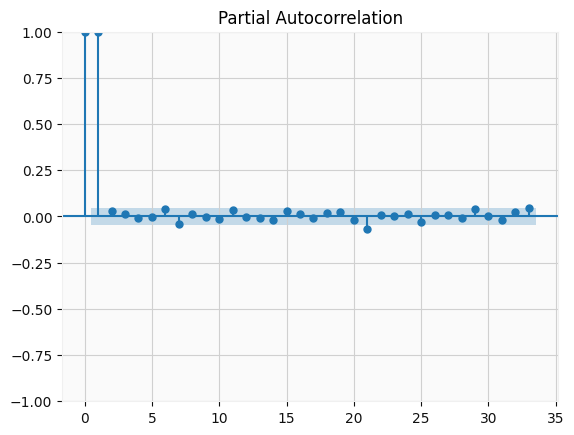

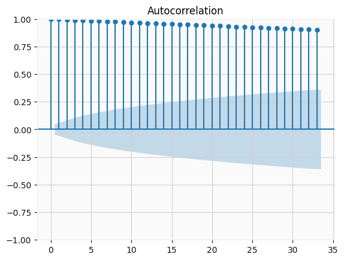

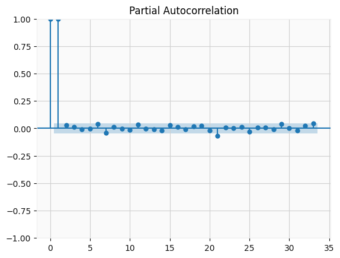

```python
from statsmodels.graphics.tsaplots import plot_acf, plot_pacf
plot_acf(train['Close'])
plot_pacf(train['Close'])
```

Way to determine the number of lags is to fit the model with different numbers of lags and compare the goodness of fit using a criterion such as the Akaike Information Criterion (AIC) or the Bayesian Information Criterion (BIC). Basically these criteria will take into account both the goodness of fit of the model and the complexity of the model (in terms of the number of parameters), with a penalty for more complex models. ploting autocorrelation plot or partial auto correlation plot .

1. Akaike Information Criterion (AIC): The AIC is derived from information theory and is used for model selection. It balances the goodness of fit and the complexity of the model. The formula for AIC is: AIC = -2 *log-likelihood + 2* k,

where:

log-likelihood: The maximized log-likelihood of the model, which measures how well the model fits the data.

k: The number of parameters in the model, which represents the complexity or the number of estimated parameters.

The AIC penalizes models with more parameters, aiming to find a balance between model fit and parsimony. The goal is to select the model with the lowest AIC value, indicating a better trade-off between fit and complexity.

1. Bayesian Information Criterion (BIC): The BIC, also known as the Schwarz criterion, is based on Bayesian statistics. It is another criterion for model selection that considers the goodness of fit and model complexity. The formula for BIC is: BIC = -2 *log-likelihood + log(n)* k,

where:

n: The sample size, the number of observations in the dataset.

The BIC penalizes models more strongly for model complexity than the AIC, particularly for smaller sample sizes (as indicated by the term log(n) * k). Like the AIC, the goal is to select the model with the lowest BIC value.

Both AIC and BIC aim to strike a balance between model fit and complexity, but they apply different penalties for model complexity. The AIC is generally more lenient in penalizing complex models compared to the BIC. The appropriate criterion to use depends on the specific context and the desired balance between fit and complexity.

1. Hannan-Quinn Information Criterion (HQIC): is another criterion used for model selection and comparison. It shares similarities with AIC and BIC but incorporates an additional penalty term for model complexity.

The formula for HQIC is as follows:

HQIC = -2 *log-likelihood + 2* k * log(log(n)),

where:

Similar to AIC and BIC, the goal is to select the model with the lowest HQIC value. HQIC provides a trade-off between model fit and complexity, considering the sample size in the penalty term.

Compared to AIC, HQIC applies a stronger penalty for model complexity, while BIC imposes a stronger penalty than both AIC and HQIC. The appropriate criterion to use depends on the specific context and the desired balance between fit and complexity.

Including HQIC alongside AIC and BIC in model selection allows for a more comprehensive evaluation, considering different perspectives on model fit and complexity.

```python
from statsmodels.tsa.ar_model import AutoReg
best_aic = np.inf
best_lag = None
best_model = None
for lag in range(40,50):
    df_ar = train['Close_diff'].dropna()
    model = AutoReg(df_ar, lags=lag, old_names=False)
    model_fit = model.fit()
    pr = round(model_fit.aic)
    int(lag, pr)
    if model_fit.aic < best_aic:
        best_aic = model_fit.aic
        best_lag = lag
        best_model = model_fit

print('Best AIC: ', best_aic)
print('Best lag order: ', best_lag)
```

[output not shown]

1. Evaluating higher order lags by investigate the ACF and PACF plots. If there are any significant autocorrelations or partial autocorrelations at specific lags. These plots may provide guidance on selecting a reasonable upper limit for the lag order.
2. Examine the residuals of the AR models fitted with different lag orders. Look for patterns or systematic behaviors in the residuals. If the residuals exhibit significant autocorrelation or other undesirable characteristics, it suggests that the selected lag order is not adequately capturing the underlying dynamics. In such cases, it may be necessary to reconsider the lag order selection.
3. Use cross-validation techniques to evaluate the out-of-sample performance of different lag orders. Split your data into training and testing sets, fit AR models with various lag orders on the training data, and evaluate their performance on the testing data. Select the lag order that produces the best forecasting accuracy or model performance on unseen data.

As decreasing trend in AIC values persists across various lag orders, it may indicate that an AR model is not the most appropriate choice for your data. we should explore alternative models such as moving averages (MA), autoregressive moving average (ARMA), autoregressive integrated moving average (ARIMA), or other time series models that can capture more complex dynamics or account for other factors affecting your data.

```python
#def autoreg(start_date,end_date, num_periods,):
from statsmodels.tsa.ar_model import AutoReg
df_ar = train['Close_diff'].dropna()
model_ar = AutoReg(df_ar, lags=50)
model_ar_fit = model_ar.fit()
print(model_ar_fit.aic, model_ar_fit.hqic, model_ar_fit.bic)
predictions_ar = model_ar_fit.predict(start='2023-01-03', end='2023-09-30', dynamic=False)
n_periods = 7
forecast = model_ar_fit.forecast(steps=n_periods)
# The forecast variable is an array of the forecasted values
print('Forecast: ', forecast)
```

```
7730.297811409749 7834.840845754666 8012.540231117459
Forecast:  2023-10-01    0.841005
2023-10-02   -0.655193
2023-10-03    0.478064
2023-10-04   -0.180578
2023-10-05   -0.043209
2023-10-06    0.135359
2023-10-07    0.469849
Freq: D, dtype: float64
```

```python
forecast_undiff = np.r_[train['Close'][-1], forecast].cumsum()
df_forecast = pd.DataFrame({'Close': forecast_undiff[1:]}, index=pd.date_range(start=test.index[0], periods=n_periods, freq='D'))
```

```python
train['Close'][-1]
```

```
127.12000274658203
```

```python
df_forecast
```

|  | Close |
| --- | --- |
| 2023-10-01 | 127.961007 |
| 2023-10-02 | 127.305814 |
| 2023-10-03 | 127.783878 |
| 2023-10-04 | 127.603301 |
| 2023-10-05 | 127.560092 |
| 2023-10-06 | 127.695451 |
| 2023-10-07 | 128.165299 |

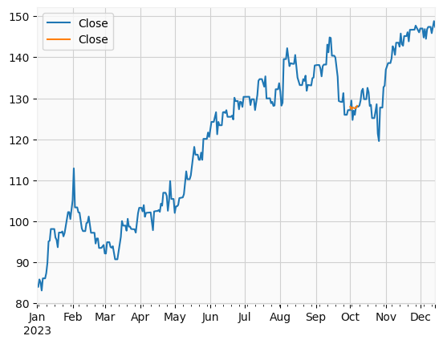

```python
df1_filtered = data[data.index >= '2023-01-01']
pd.concat([df1_filtered['Close'],df_forecast],axis=1).plot()
```

## MA : Moving Averages

## ARIMA : Autoregressive Integrated Moving Average

ARIMA models are widely used for modeling and forecasting time series data. They capture the linear dependencies between past observations and use differencing to handle non-stationarity. ARIMA models are effective for capturing short-term patterns and can be tuned with parameters such as autoregressive (p), differencing (d), and moving average (q) components.

### Some question/Challenges

[output not shown]

[figure not shown]

```python
# CandlePlot for Sep2019 to Dec 2019
fig,ax = plt.subplots(figsize=(8,4))
def candlestick(df,ax):
    ax.vlines(x=df.index, ymin=df.Low, ymax=df.High, color='r', linewidth=1)
    red = df.query('Open > Close')
    ax.vlines(x=red.index,ymin=red.Close, ymax=red.Open, color='r', linewidth=3)
    green = df.query('Open <= Close')
    ax.vlines(x=green.index,ymin=green.Open, ymax=green.Close, color='g', linewidth=3)
    ax.xaxis.set_major_locator(dates.MonthLocator())
    ax.xaxis.set_major_formatter(dates.DateFormatter('%b-%y'))
    ax.xaxis.set_minor_locator(dates.DayLocator())
    return df
(data
 .iloc[:,::2]
 .pipe(fix_col)
 .resample('d')
 .agg({'Close':'last', 'Open':'first',  'High':'max', 'Low':'min'})
 .loc['Sep 2019':'Dec 2019']
 .pipe(candlestick,ax)
)
```

```python
#Returns

app = (data
       .iloc[:,::2]
       .pipe(fix_col)
      )

app
```

[output not shown]

```python
app.diff()
```

[output not shown]

```python
# percentage change r2-r1/r2
app.pct_change()
```

[output not shown]

[figure not shown]

```python
# Plotting return
(app
 .pct_change()
 .Close
 .plot()
)
```

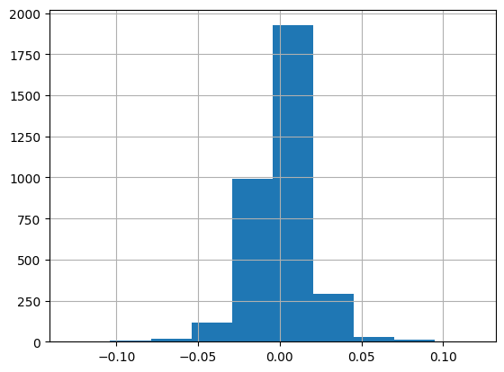

```python
(app
 .pct_change()
 .Close
 .hist()
)
```

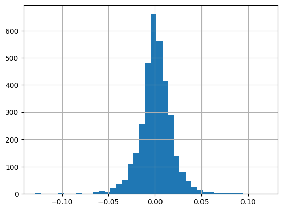

```python
(app
 .pct_change()
 .Close
 .hist(bins=40)
)
```

#